# Introduction to meta-analysis

Steve Simon

11/14/2018

## Overview

This presentation will show how to use base R functions to reproduce the elements of a forest plot. It will also offer some suggestions on how you should interpret patterns in this plot.

## BCG description

“Results from 13 studies examining the effectiveness of the Bacillus Calmette-Guerin (BCG) vaccine against tuberculosis.”

The BCG data comes with the metafor package in R, but is also available at https://rdrr.io/cran/metafor/man/dat.colditz1994.html

## BCG data, first three columns

```
##    trial               author year
## 1      1              Aronson 1948
## 2      2     Ferguson & Simes 1949
## 3      3      Rosenthal et al 1960
## 4      4    Hart & Sutherland 1977
## 5      5 Frimodt-Moller et al 1973
## 6      6      Stein & Aronson 1953
## 7      7     Vandiviere et al 1973
## 8      8           TPT Madras 1980
## 9      9     Coetzee & Berjak 1968
## 10    10      Rosenthal et al 1961
## 11    11       Comstock et al 1974
## 12    12   Comstock & Webster 1969
## 13    13       Comstock et al 1976
```

## BCG data, last six columns

```
##    tpos  tneg cpos  cneg ablat      alloc
## 1     4   119   11   128    44     random
## 2     6   300   29   274    55     random
## 3     3   228   11   209    42     random
## 4    62 13536  248 12619    52     random
## 5    33  5036   47  5761    13  alternate
## 6   180  1361  372  1079    44  alternate
## 7     8  2537   10   619    19     random
## 8   505 87886  499 87892    13     random
## 9    29  7470   45  7232    27     random
## 10   17  1699   65  1600    42 systematic
## 11  186 50448  141 27197    18 systematic
## 12    5  2493    3  2338    33 systematic
## 13   27 16886   29 17825    33 systematic
```

```
Fixed-Effects Model (k = 13)

Test for Heterogeneity:
Q(df = 12) = 163.1649, p-val < .0001

Model Results:

estimate      se      zval    pval    ci.lb    ci.ub
 -0.4361  0.0423  -10.3190  <.0001  -0.5190  -0.3533  ***

---
Signif. codes:  0 '***' 0.001 '**' 0.01 '*' 0.05 '.' 0.1 ' ' 1
```

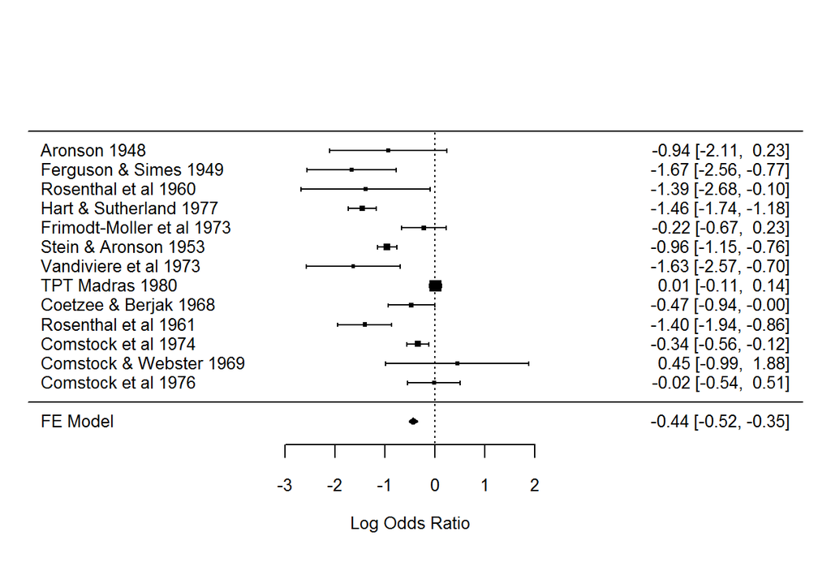

Here are the results for the first study, listed in a two by two table. A positive result is listed in the first column and a negative result in the second column. A positive result is bad, indicating that the vaccine did not work.

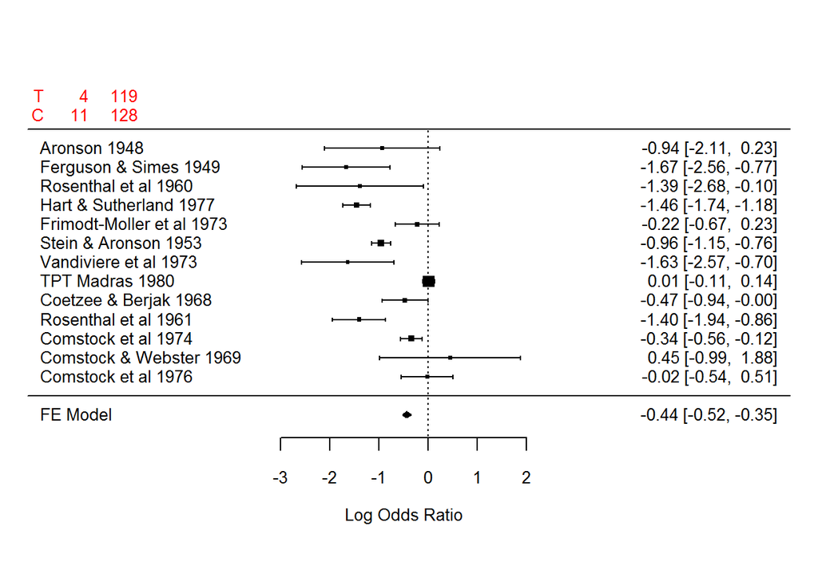

Calculate the odds for each row.

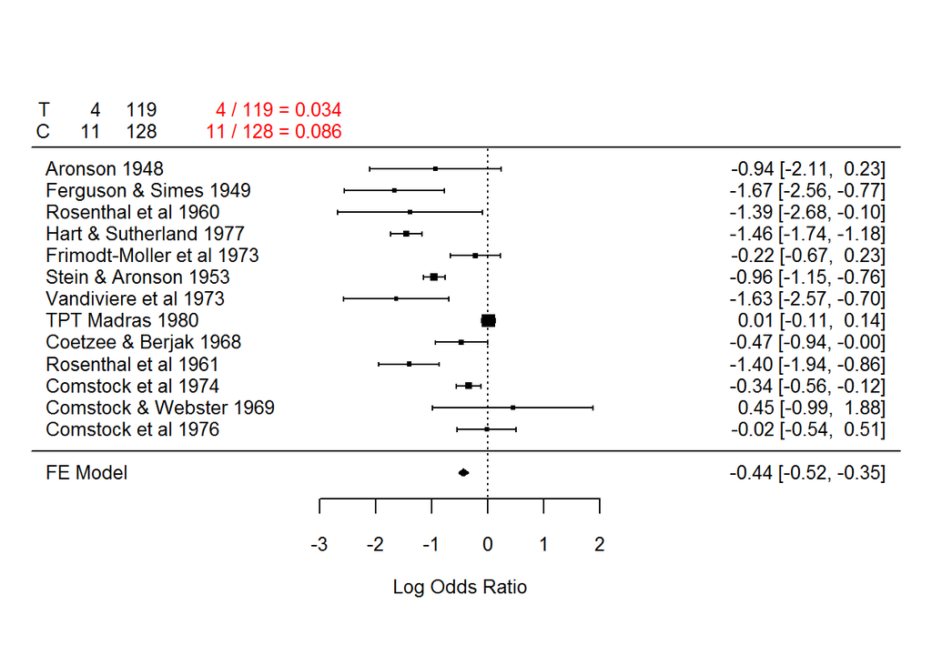

The ratio of these two odds is the odds ratio.

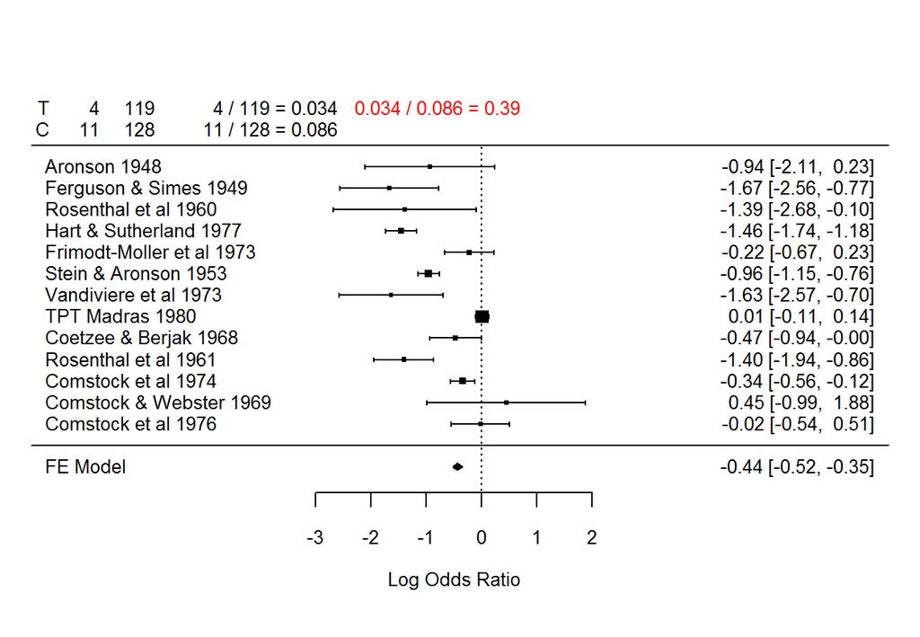

The underlying distribution of the odds ratio is almost always skewed right and bounded below by zero, so you should consider a log transformation. This is the center of the confidence interval for the first study

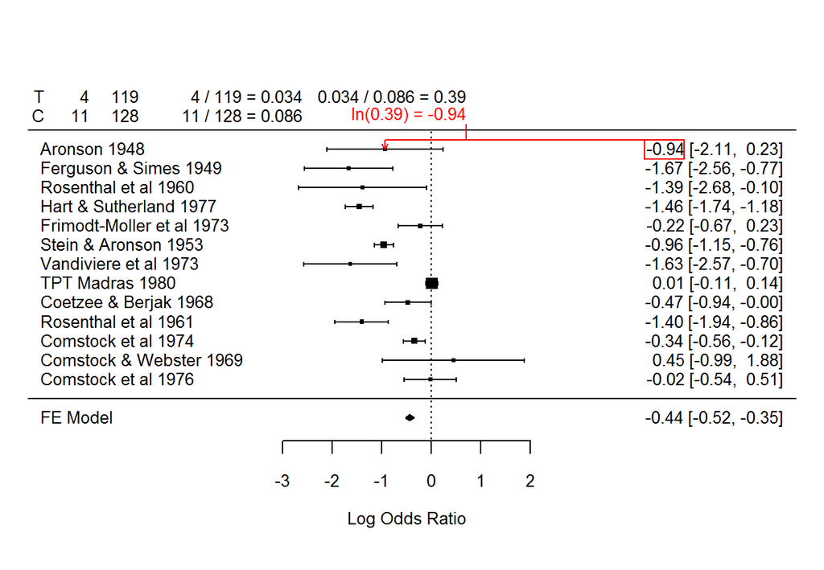

Repeat these calculations for the second,

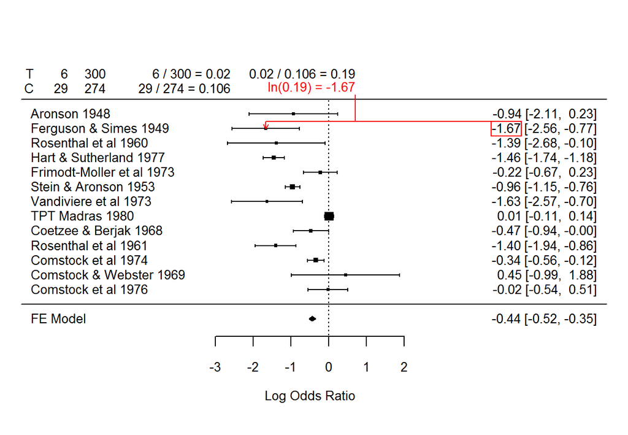

third,

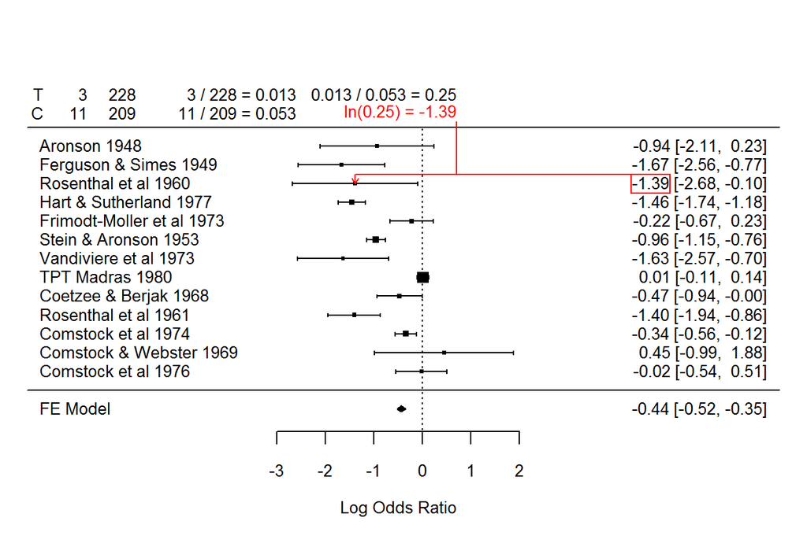

fourth,

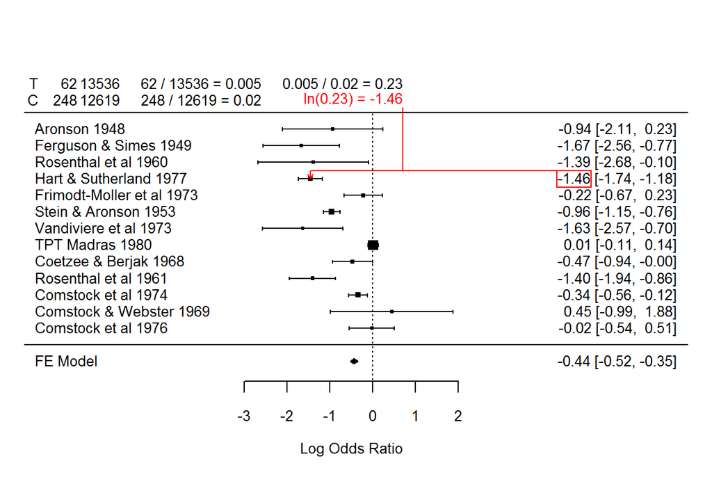

fifth,

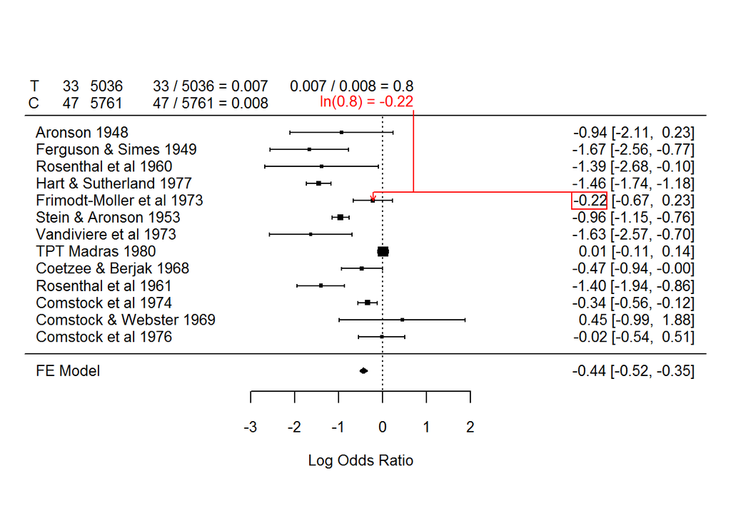

sixth,

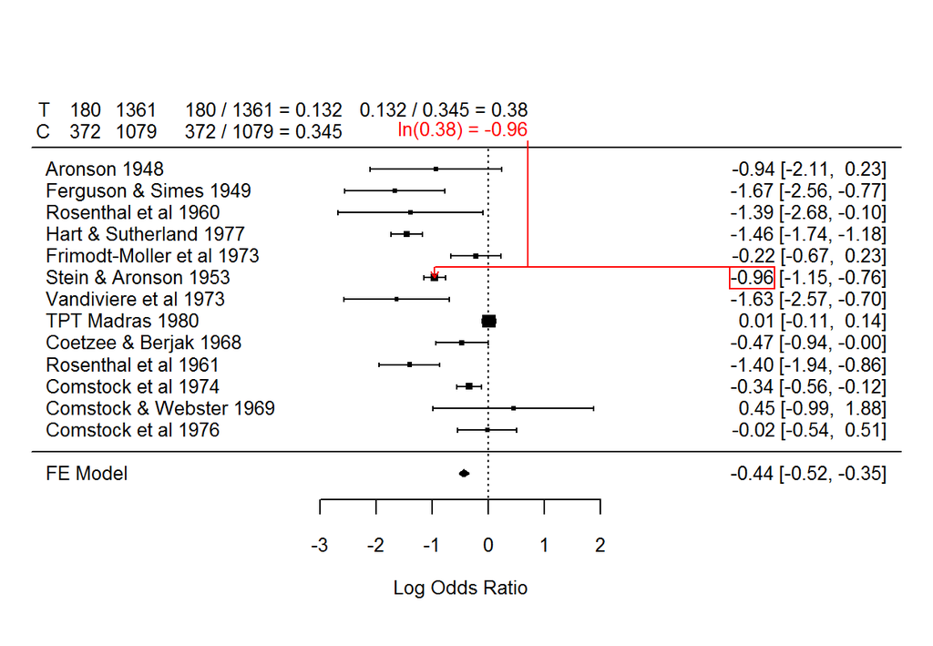

seventh,

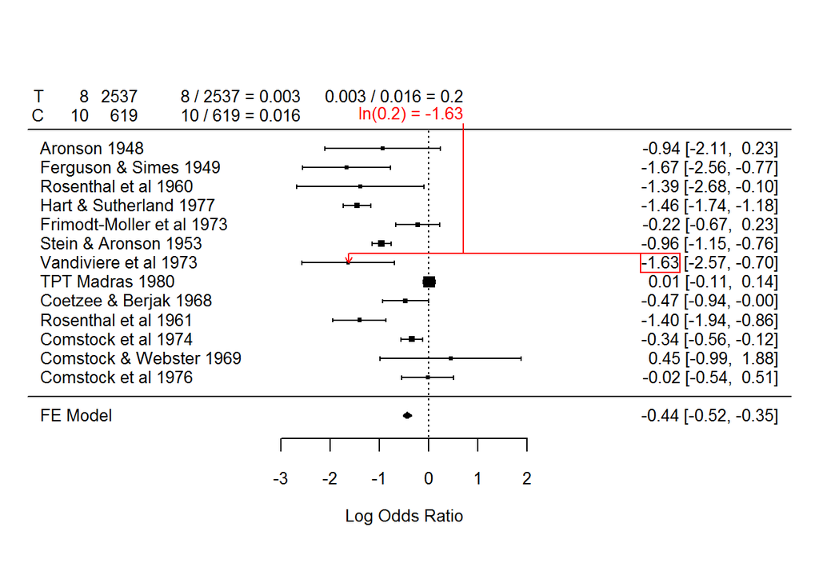

eighth,

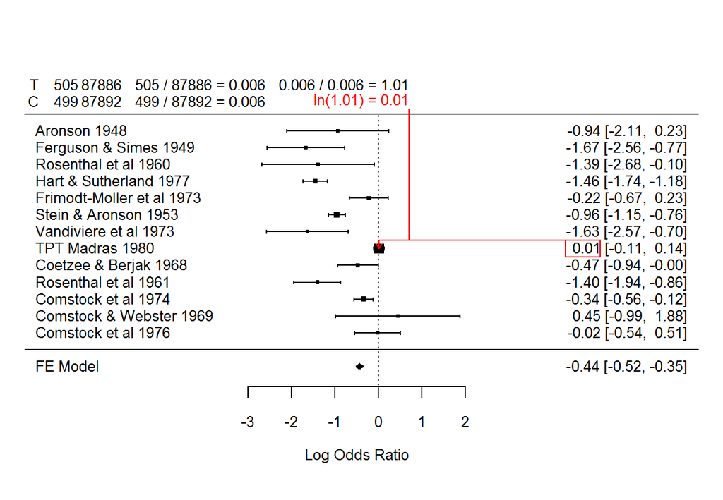

ninth,

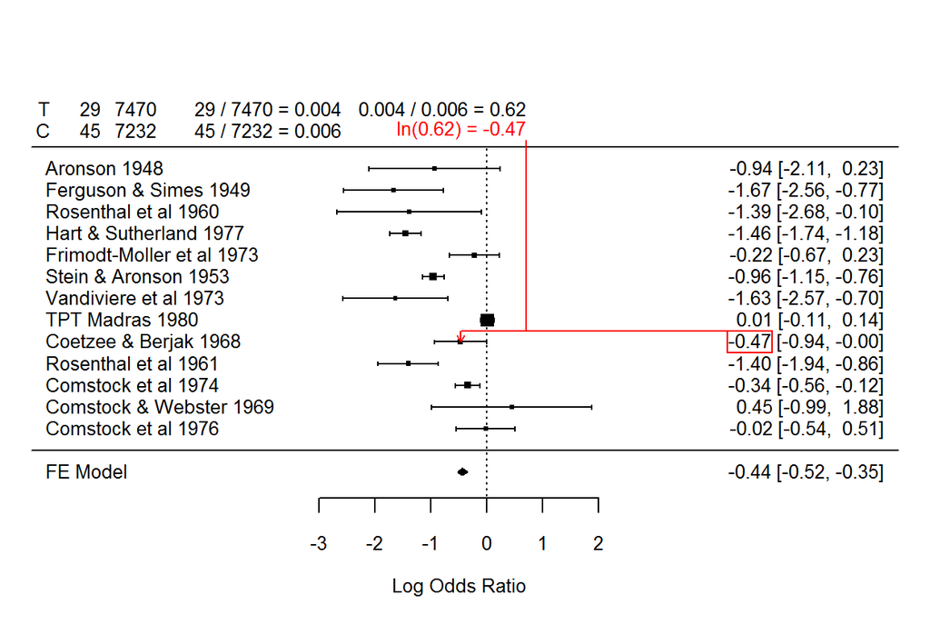

tenth,

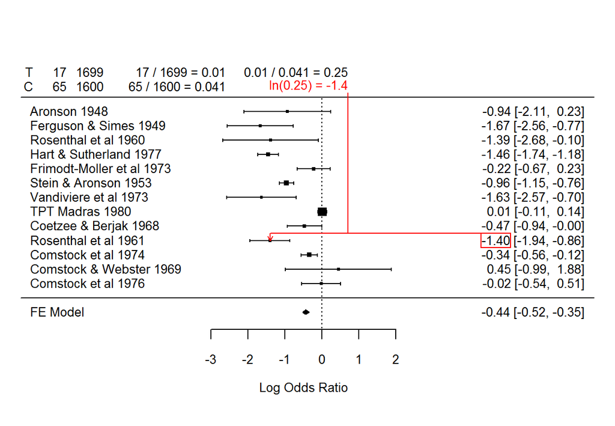

eleventh,

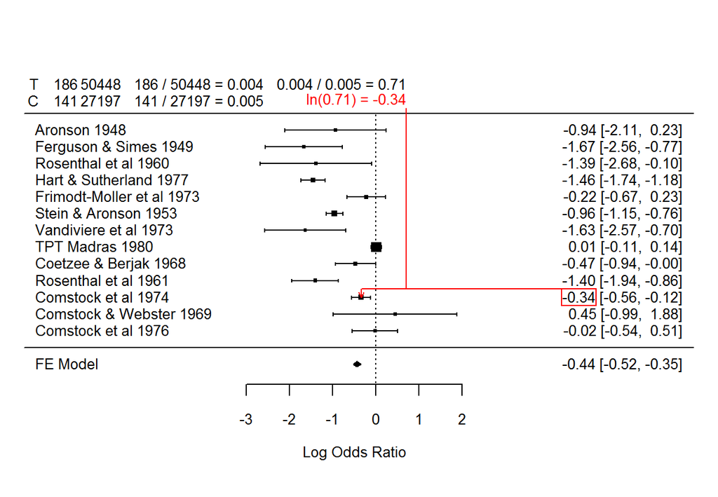

twelvth,

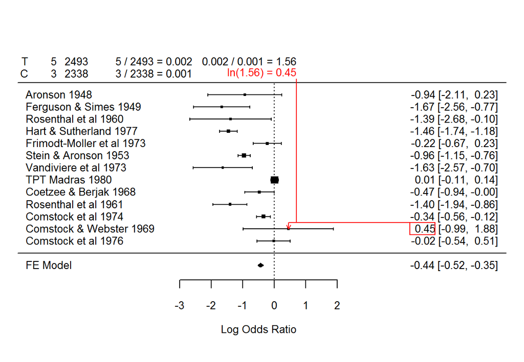

and thirteenth studies.

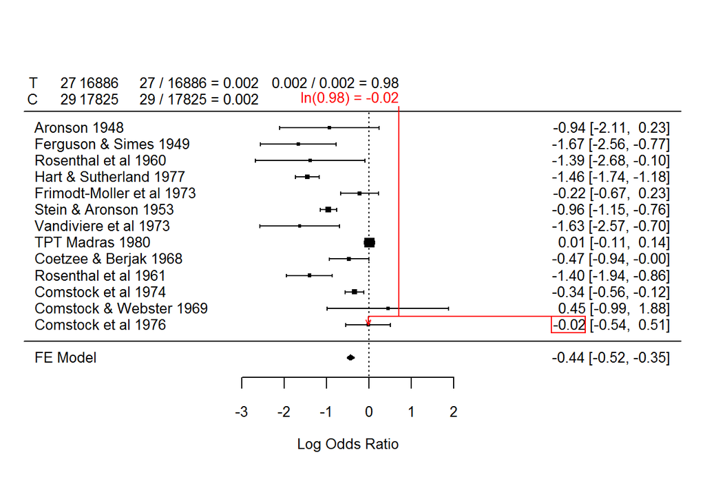

The variance of the log odds ratio is approximately

$\frac{1}{n_{11}} + \frac{1}{n_{12}} + \frac{1}{n_{21}} + \frac{1}{n_{22}}$

where n11, n12, etc. are the count of each cell in the two by two table. For the first study, you get

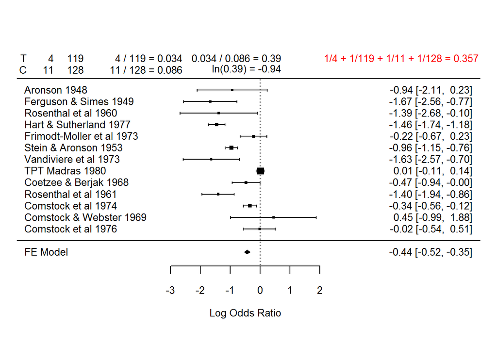

The approximate confidence interval for the log odds is

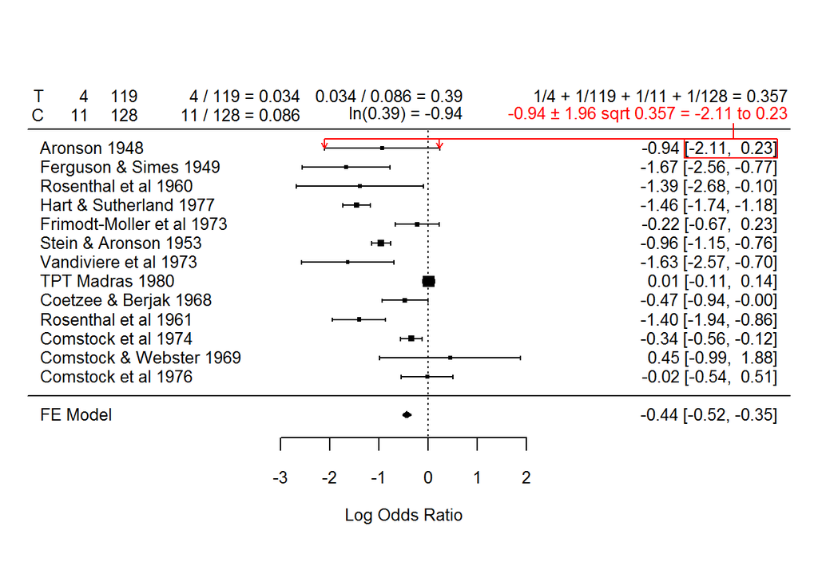

Notice that this confidence interval includes the value of zero, so this particular study did not reject the null hypothesis.

Repeath this calculation for the second,

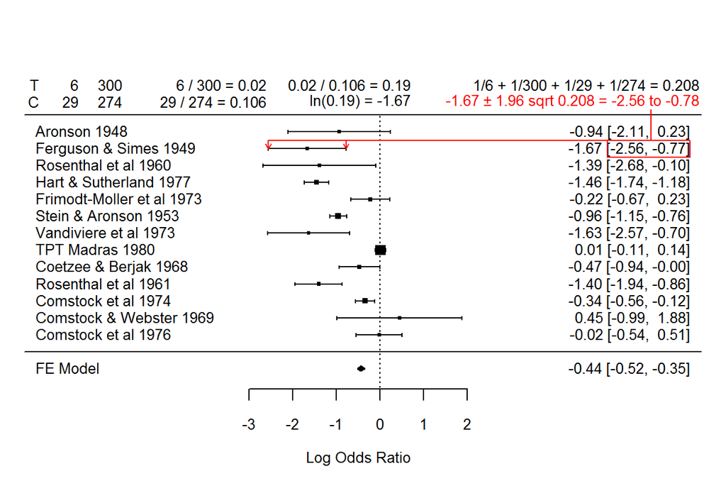

third,

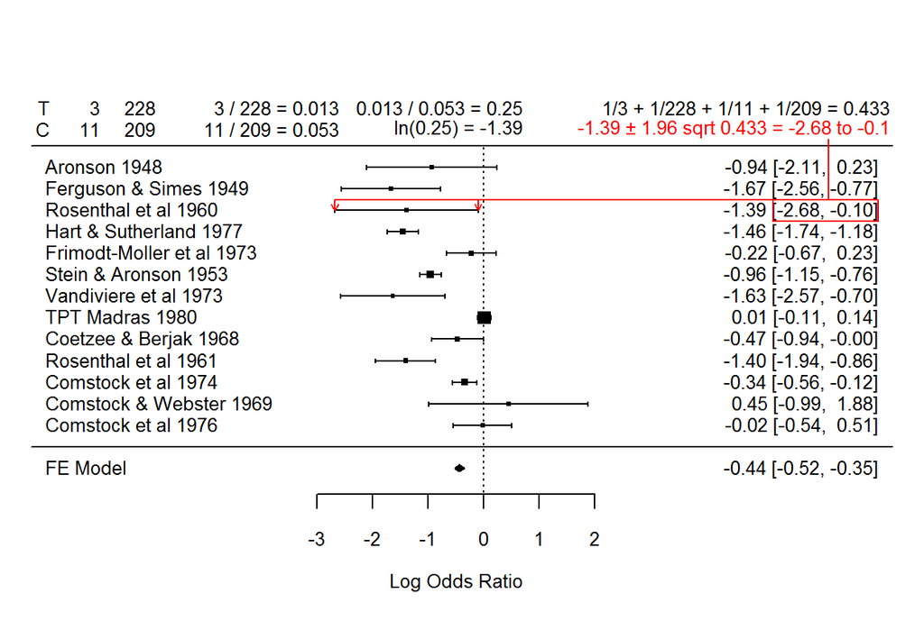

fourth,

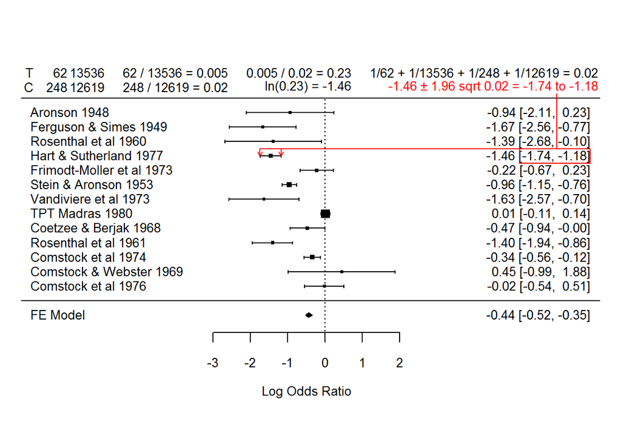

fifth,

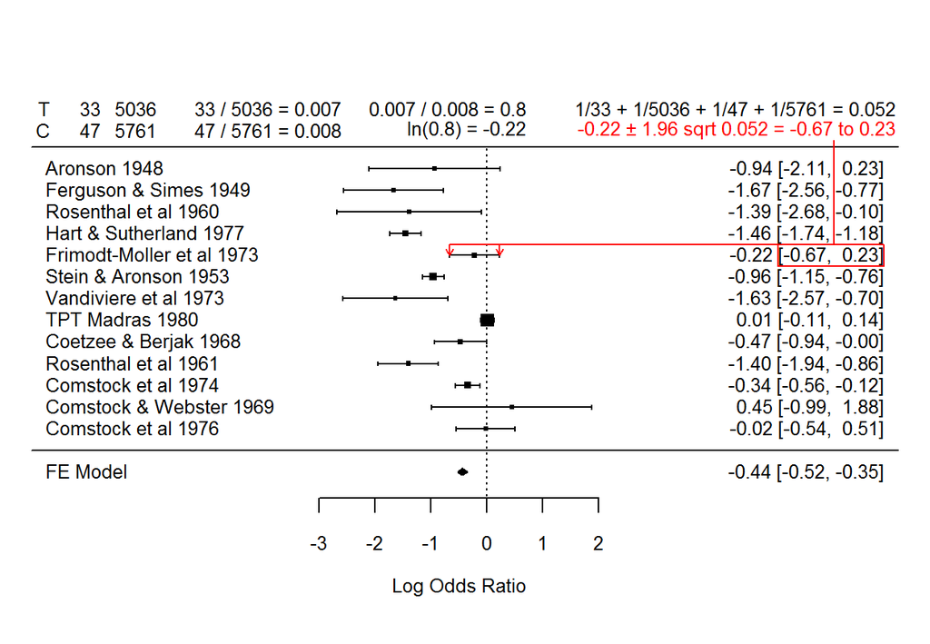

sixth,

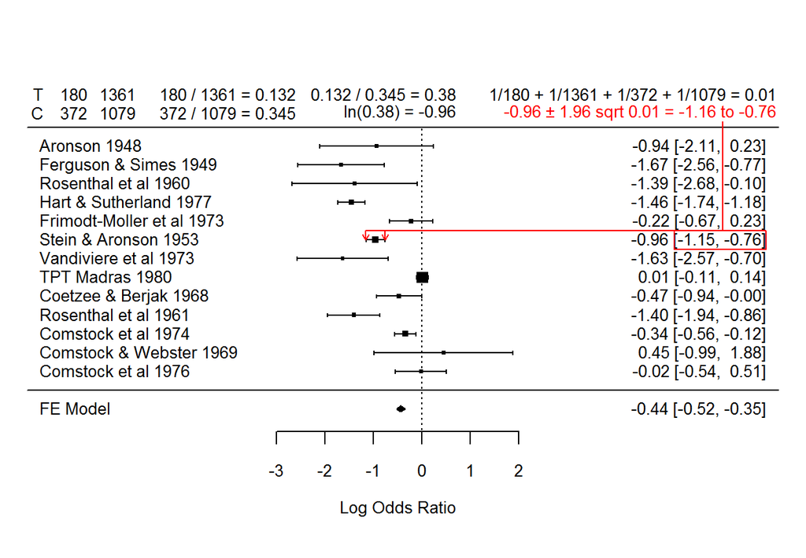

seventh,

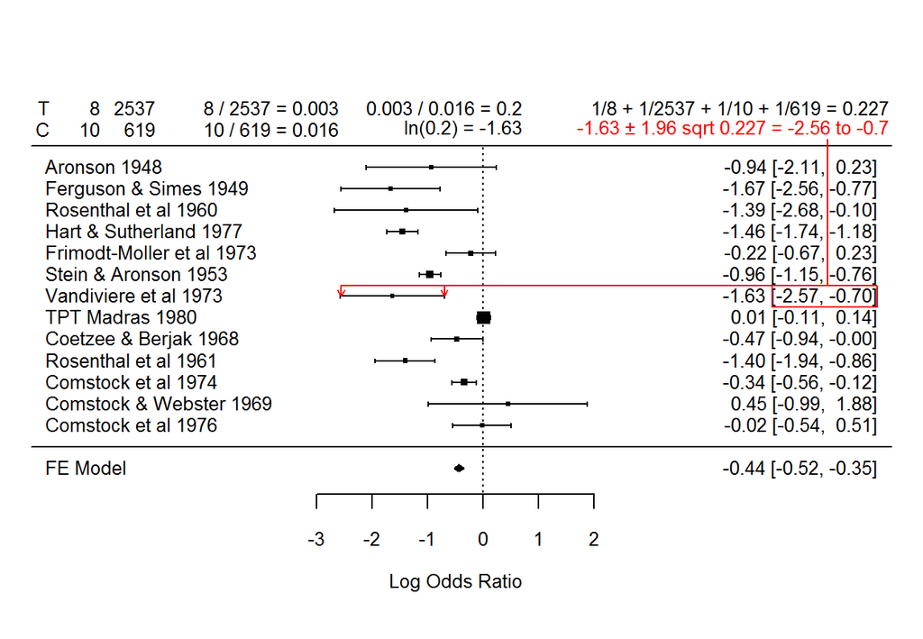

eighth,

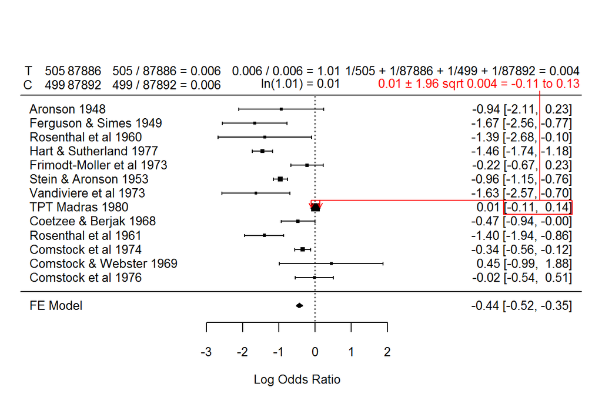

ninth,

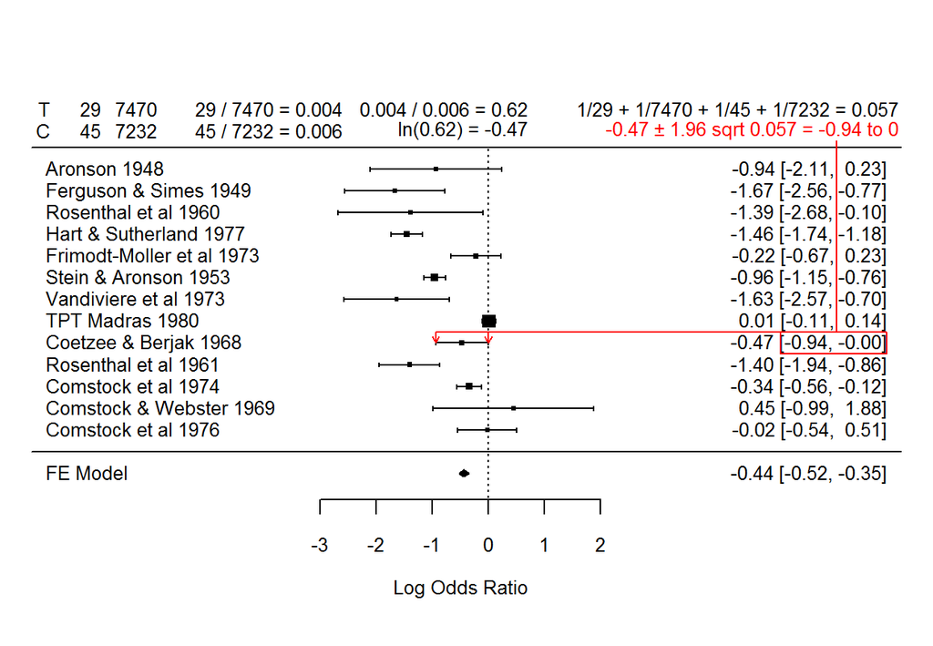

tenth,

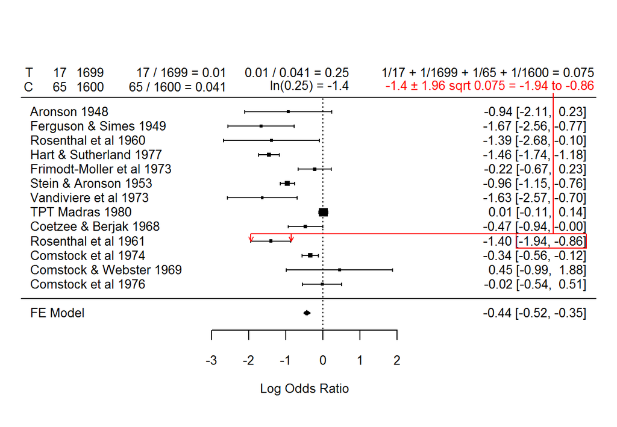

eleventh,

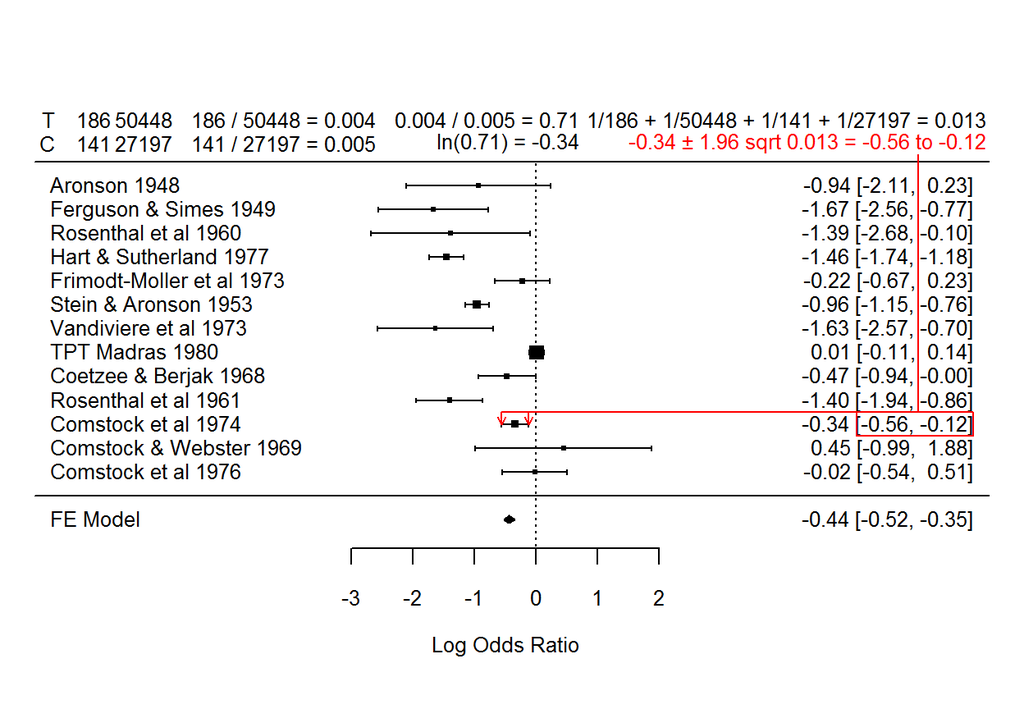

twelvth,

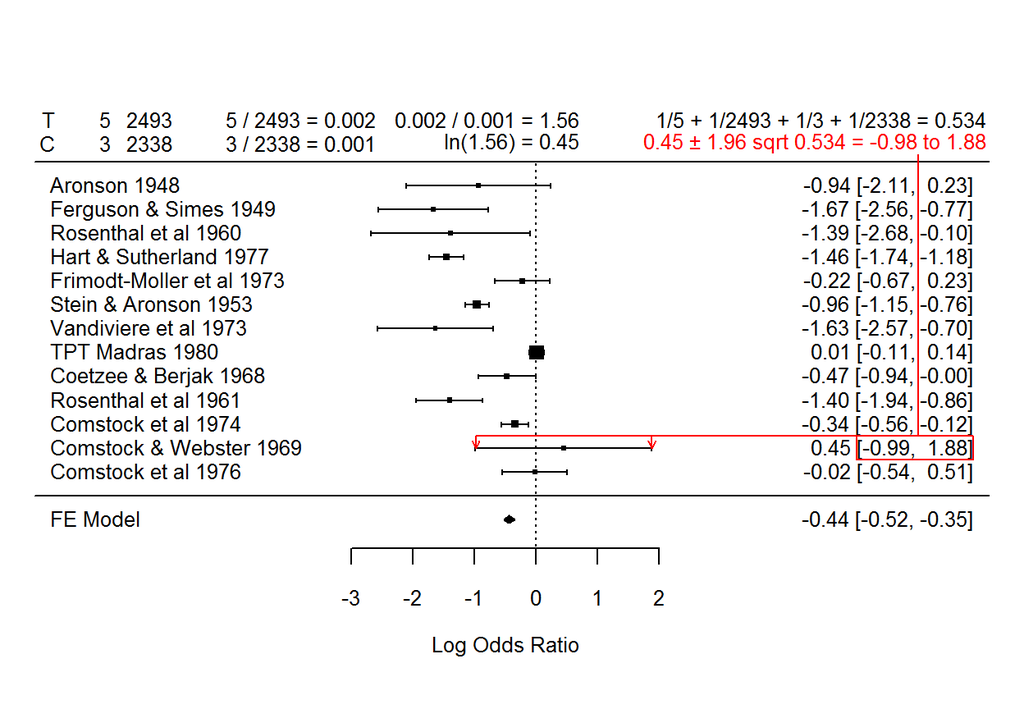

and thirteenth studies.

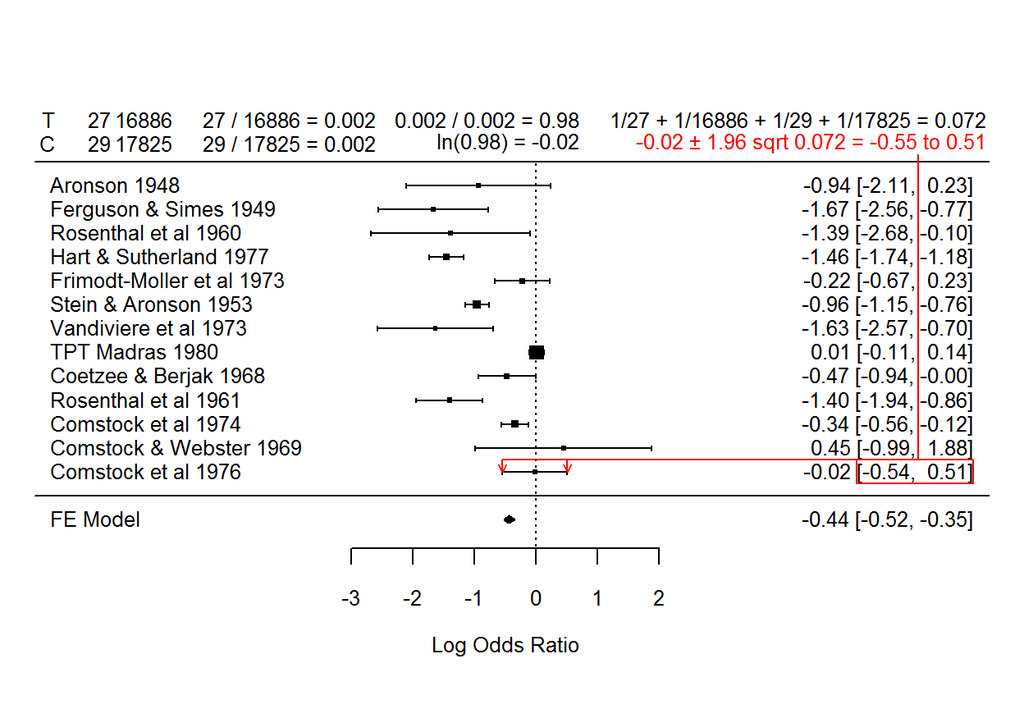

[output not shown]

The overall estimate is a weighted average of the individual study estimates.

$\hat{\theta}=\frac{\Sigma \hat{\theta}_i w_i}{\Sigma w_i}$

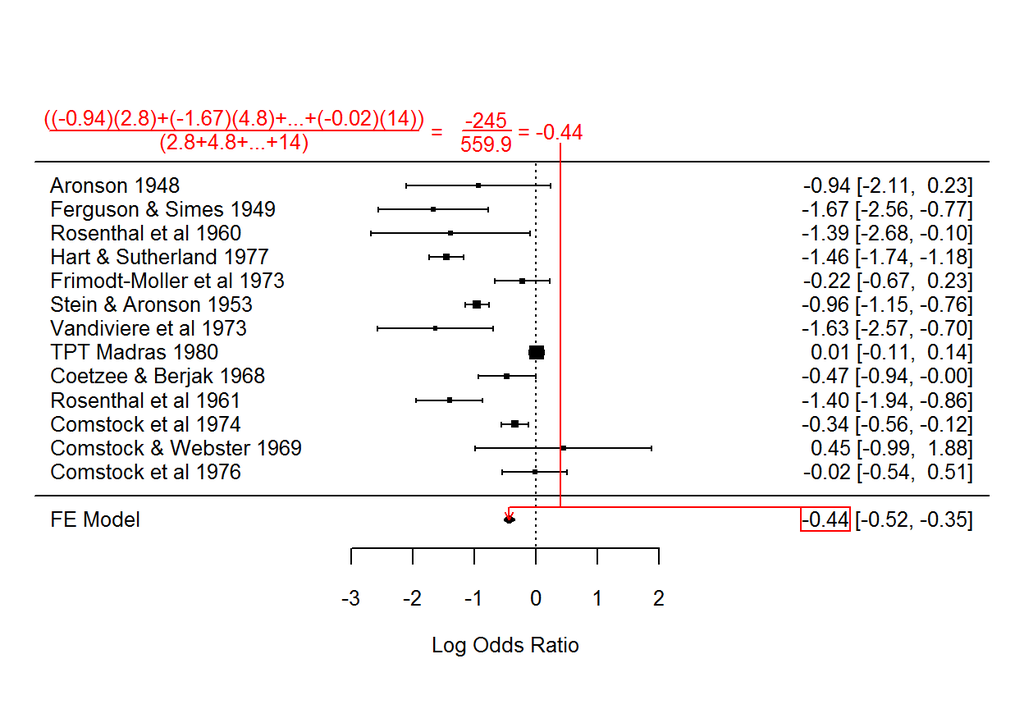

The variance of the overall estimate is simply the reciprocal of the sum of the weights.

$V(\hat{\theta})=\frac{1}{\Sigma w_i}$

This is just the fraction seen above, but with the nuermator replaced by 1.

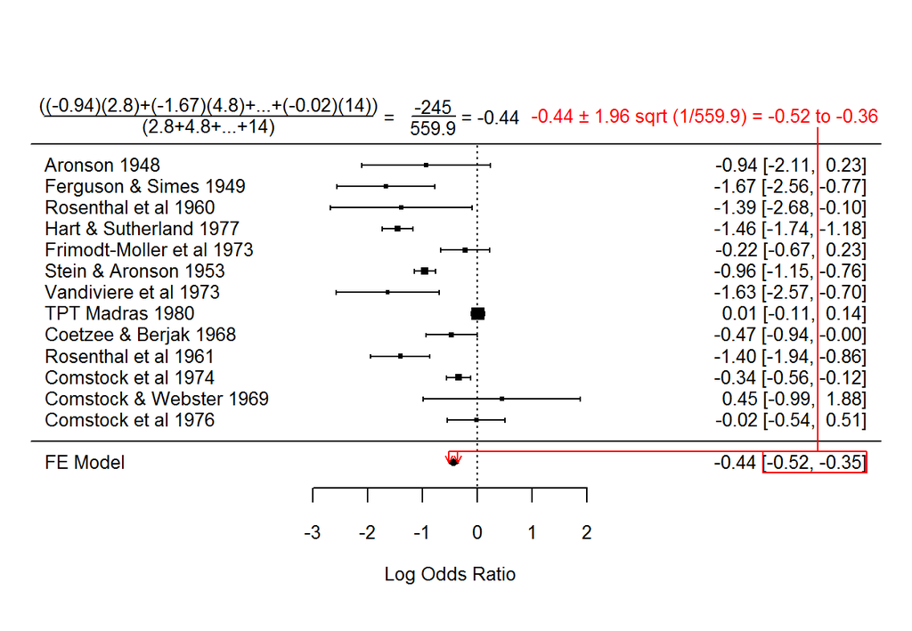

The relative weights given to each study are listed below.

```
##    study    wt rel_wt
## 1      1   2.8   0.5%
## 2      2   4.8   0.9%
## 3      3   2.3   0.4%
## 4      4  49.2     9%
## 5      5  19.2     3%
## 6      6 101.0    18%
## 7      7   4.4   0.8%
## 8      8 249.6    45%
## 9      9  17.6     3%
## 10    10  13.3     2%
## 11    11  79.8    14%
## 12    12   1.9   0.3%
## 13    13  14.0     3%
## 14 Total 559.9  99.9%
```

The relative weights determine the size of the squares in the forest plot.

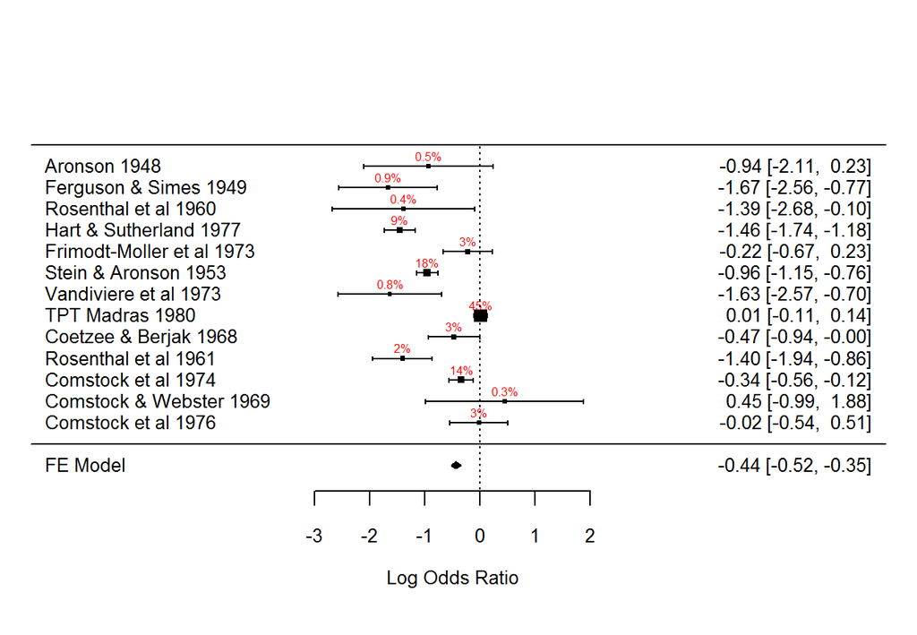

Finally, notice a dotted vertical line at the log odds ratio=0. This is the null value.

## What to look for in a forest plot

The forest plot provides information about individual studies, and how they relate to the overall estimate. Here are some things to look for.

1. Look at the overall effect first. Does the overall confidence interval diamond intersect the vertical dotted line of no effect?
2. Count the number of individual studies which fail to achieve statistical significance. These are individual confidence intervals that intersect the vertical dotted line. The count of non-significant studies is not a primary measure of evidence, because you can easily have a meta-analysis where every single individual study is not statistically significant, but the overall result is strongly significant. Still, it’s an interesting measure, and gives you an initial impression of what the exisiting publications have said so far.
3. Count the number of studies where the point estimate is on the “wrong” side of the dotted line. Again, this is not a primary measure of evidence. Informally, a meta-analysis strengthens the results of each individual study if all the individual studies are pointing in the same direction. A few studies pointing in the opposite direction will tend to dilute the strength of a meta-analytic finding (as they should).
4. Look at the relative weights given to each study. Does one study tend to dominate the findings?
5. Look for evidence of heterogeneity. This can occur several ways, but the easiest source of heterogeneity is a bimodal pattern in the studies. Most of the studies might show little or no effect, for example, but a smaller group of studies might cluster in a region of a strong effect. If you are familiar with the individual studies, ask yourself if there is a feature that is unique to the outlying cluster of studies.